# Sample questions on exponential growth for BIOL 150

BIOL 458

17/11/2023

# Questions

## Question 1

Recently, a new strain of Coronavirus (COVID X) was introduced to Canada. the strain behaves differently than earlier strains, and much like at the start of the COVID pandemic, no one has any immunity. Everyone is susceptible.

If you were a member of a health committee tasked with minimizing the number of infections, how could you reduce the rate of disease transmission? After implementing your suggestion, how would this alter the curve in the plot?

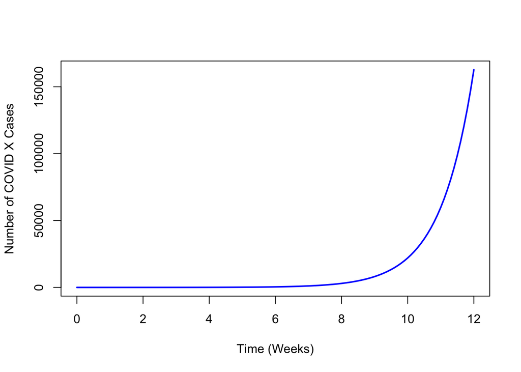

## Question 2

A population of rabbits was introduced to the University of Waterloo campus in 2015. The president explained that “We need to mitigate the negative impacts of loneliness on campus. Our geese on campus need to interact with more species”. Seemed weird. Anyway, since rabbits have many overlapping generations per year, we can use the exponential growth equation:
$$N_t=N_0 e^{rt},$$

## Question 3

An invasive species Common buckthorn (*Rhamnus cathartica*) has been filling up the woodlots and wild spaces of Ontario that used to be occupied by native trees https://www.invadingspecies.com/invaders/plants/common-buckthorn-2/. It produces large numbers of seeds once a year that germinate quickly, and then forms dense stands that prevent the growth of native trees and shrubs. If that wasn’t enough, this species can host oat rust, a fungus that causes leaf and crown rust and affects the yield and quality of oats, and the soybean aphid, an insect that damages soybean crops. Because it can affect agricultural crops, common buckthorn is listed as a noxious weed under Ontario’s Weed Control Act.

You notice a big buckthorn tree filled with berries in a 1 hectare woodlot near your house, nearby are 5 smaller trees that all look to be one year old. If you take no action, how many buckthorn trees do you expect to see 3 years from now?

[figure not shown]

Common buckthorn, photo by R.A.Nonenmacher, CC BY-SA 4.0 https://creativecommons.org/licenses/by-sa/4.0, via Wikimedia Commons

## Question 4

You have been studying a population of *Daphnia pulex*, a type of zooplankton, for a few years.

You know that the Daphnia population grows exponentially and initially had a per capita intrinsic growth rate, r, of 1.2. You then noticed that although the population continues to grow exponentially, the growth rate has decreased to 0.36. If r continues to be 0.36, will the population size start decreasing? Explain why or why not.

## Question 5

A new beetle species, *Harrya Pottertae*, has recently been discovered in the English countryside. Quite magically, researchers have noticed that the population has been increasing rapidly with overlapping generations. The population of the beetles was initially 13 individuals per metre squared and has grown to about 934 individuals per metre squared in the span of 8 days.

1. Is this an example of exponential or geometric growth rate?
2. What is the instantaneous rate of increase for this new beetle species? Remember $e^x=y$ is equal to $\ln y=x$.

# Answers

## Answer 1

The plot above is depicting exponential growth, which is sometimes referred to as a “J-shaped” curve or a “Hockey Puck” curve.

One possible solution to curbing the exponential growth of COVID X is vaccination. Vaccination has been shown to prevent epidemics by interrupting the spread of the disease even if some members of the population remain unvaccinated. This occurs through a phenomenon known as herd immunity, where the spread of the disease in a population becomes significantly limited after a minimum proportion of the population has been vaccinated.

After vaccination, the fixed rate of transmission, which is characteristic of exponential growth of diseases, would decrease. Since the rate of transmission is given by the slope of the curve at any given point, the curve would begin to plateau as the transmission rate decreases.

## Answer 3

Since berries are produced only once a year, this is an example of geometric population growth. We can predict future population size using the equation: $N_t=\lambda N_0^t$, where is the annual population growth rate. We don’t have a lot of data, but let’s try!

Current population size = 6/hectare, and clearly started from the one tree. We don’t really know how old that tree is but, let’s just assume it is two years old, so that t = 1 year. Rearranging and substituting in we an solve for $\lambda$ as:
$$\begin{aligned}
N_2&=\lambda N_1^t \\
\lambda&= \frac{N_2}{N_1^t}\\
\lambda&=\frac{6}{1^1} \\
\lambda&=6
\end{aligned}$$
Now that we have the population growth rate, we can use it to predict population size 3 years from now, if our starting population size is 6 individuals/hectare.

$$\begin{aligned}
N_{3}&=\lambda N_0^3 \\
N_{3}&=6(6^3) \\
N_{3}&=1296
\end{aligned}$$
Gulp!! That’s 1296 trees in a one hectare woodlot!! Better take some action!

## Answer 4

No, the population size will not decrease because r is still greater than 0. Recall that for exponential growth, the population size increases when r > 0, decreases when r < 0, and remains the same when r = 0. Therefore, because r is smaller than it was initially but is still greater than 0, the population size will now grow more slowly, but will not start decreasing.

[figure not shown]

*Daphnia Pulex*. Yale Peabody Museum, CC0, via Wikimedia Commons